# Study 2: Three-Condition Experiment

Published

October 7, 2026

```r
library(tidyverse)
library(arrow)
library(emmeans)
library(effectsize)
library(gt)
library(patchwork)

# Paths
base_path <- here::here("studies/02_experimental/")
fig_path  <- file.path(base_path, "output/figures/")
tab_path  <- file.path(base_path, "output/tables/")
dir.create(fig_path, recursive = TRUE, showWarnings = FALSE)
dir.create(tab_path, recursive = TRUE, showWarnings = FALSE)

# Ground truth Republican GREEN mean (from Twin-2K-500 dataset, N = 540 Republicans)
GROUND_TRUTH_GREEN <- 3.18

# Condition colors
condition_colors <- c("Control" = "#BDBDBD", "GPT Persona" = "#67A9CF", "Digital Twin" = "#2166AC")

# Helper functions
pformat <- function(p, digits = 3) {
  if (is.na(p)) return("NA")
  threshold <- 10^(-digits)
  if (p < threshold) paste0("< .", paste(rep("0", digits - 1), collapse = ""), "1")
  else paste0("= ", sprintf(paste0("%.", digits, "f"), p))
}

numformat <- function(x, digits = 2) sprintf(paste0("%.", digits, "f"), x)

p_to_stars <- function(p) {
  ifelse(p < .001, "***", ifelse(p < .01, "**", ifelse(p < .05, "*", "n.s.")))
}

knitr::opts_chunk$set(dpi = 150)
```

# Data Cleaning

```r
# Load raw Qualtrics CSV (2 metadata rows after header)
raw <- read_csv(file.path(base_path, "data/raw/qualtrics.csv"),
                col_types = cols(.default = "c"),
                show_col_types = FALSE) %>%
  slice(-(1:2))

cat("Raw rows:", nrow(raw), "\n")
```

```
Raw rows: 403
```

```r
# Filter to completed responses with condition assignment
dat <- raw %>%
  filter(Status == "IP Address") %>%
  filter(!is.na(condition) & condition != "")

# Determine party
dat <- dat %>%
  mutate(
    participant_party = case_when(
      politicalorientation == "Closer to the Republican Party" ~ "Republican",
      politicalorientation == "Closer to the Democratic Party" ~ "Democrat",
      TRUE ~ NA_character_
    )
  ) %>%
  filter(!is.na(participant_party))

# Exclude Republicans (too few for analysis)
n_rep <- sum(dat$participant_party == "Republican")
cat("Excluding", n_rep, "Republicans.\n")
```

```
Excluding 3 Republicans.
```

```r
dat <- dat %>% filter(participant_party == "Democrat")

# Clean condition labels
dat <- dat %>%
  mutate(
    treatment = factor(
      case_when(
        condition == "twin"    ~ "Digital Twin",
        condition == "persona" ~ "GPT Persona",
        condition == "control" ~ "Control",
        TRUE ~ NA_character_
      ),
      levels = c("Control", "GPT Persona", "Digital Twin")
    )
  ) %>%
  filter(!is.na(treatment))

cat("Final N:", nrow(dat), "\n")
```

```
Final N: 400
```

```r
cat("By condition:\n")
```

```
By condition:
```

```r
print(table(dat$treatment))
```

```
     Control  GPT Persona Digital Twin
         131          134          135
```

```r
# Post-treatment outgroup attitude estimates (green1-6): recode text → 1-5
recode_likert5 <- function(x) {
  case_when(
    x %in% c("Strongly disagree", "13") ~ 1L,
    x %in% c("Somewhat disagree", "14") ~ 2L,
    x %in% c("Neither agree nor disagree", "15") ~ 3L,
    x %in% c("Somewhat agree", "16") ~ 4L,
    x %in% c("Strongly agree", "17") ~ 5L,
    !is.na(suppressWarnings(as.integer(x))) ~ as.integer(x),
    TRUE ~ NA_integer_
  )
}

green_cols <- c("green1", "green2", "green3", "green4", "green5", "green6")
dat <- dat %>% mutate(across(all_of(green_cols), recode_likert5))

# Composite: mean of 6 items
dat <- dat %>%
  rowwise() %>%
  mutate(green_estimate = mean(c(green1, green2, green3, green4, green5, green6), na.rm = TRUE)) %>%
  ungroup()

# Reliability
green_alpha <- psych::alpha(dat %>% select(all_of(green_cols)), check.keys = TRUE)$total$std.alpha
cat("GREEN scale α =", numformat(green_alpha), "\n")
```

```
GREEN scale α = 0.93
```

```r
# Primary DV: absolute estimation error (lower = more accurate)
dat <- dat %>%
  mutate(
    abs_error = abs(green_estimate - GROUND_TRUTH_GREEN),
    signed_error = green_estimate - GROUND_TRUTH_GREEN
  )

# Also compute item-level errors
for (i in 1:6) {
  col <- paste0("green", i)
  dat[[paste0("abs_error_", i)]] <- abs(dat[[col]] - GROUND_TRUTH_GREEN)
  dat[[paste0("signed_error_", i)]] <- dat[[col]] - GROUND_TRUTH_GREEN
}

cat("Absolute error: M =", numformat(mean(dat$abs_error, na.rm = TRUE)),
    ", SD =", numformat(sd(dat$abs_error, na.rm = TRUE)), "\n")
```

```
Absolute error: M = 0.89 , SD = 0.57
```

```r
cat("Signed error: M =", numformat(mean(dat$signed_error, na.rm = TRUE)),
    ", SD =", numformat(sd(dat$signed_error, na.rm = TRUE)), "\n")
```

```
Signed error: M = -0.31 , SD = 1.01
```

```r
# Persuasiveness rating: recode text → 1-5
dat <- dat %>%
  mutate(
    persuasive = case_when(
      persuasive == "Not at all persuasive" ~ 1L,
      persuasive == "Slightly persuasive" ~ 2L,
      persuasive == "Moderately persuasive" ~ 3L,
      persuasive == "Very persuasive" ~ 4L,
      persuasive == "Extremely persuasive" ~ 5L,
      !is.na(suppressWarnings(as.integer(persuasive))) ~ as.integer(persuasive),
      TRUE ~ NA_integer_
    )
  )
```

```r
# Demographics
dat <- dat %>%
  mutate(
    age = as.numeric(age),
    gender = case_when(
      gender %in% c("Male", "1") ~ "Male",
      gender %in% c("Female", "2") ~ "Female",
      TRUE ~ "Other"
    )
  )

# Party strength (Democrat identification slider)
if ("Q41_2" %in% names(dat)) {
  dat$party_strength <- as.numeric(dat$Q41_2)
}

# Chatbot engagement (from embedded data)
dat$chatbot_turn_count <- as.numeric(dat$chatbot_turn_count)
```

```r
write_parquet(dat, file.path(base_path, "data/processed/analysis_data.parquet"))
write_csv(dat, file.path(base_path, "data/processed/analysis_data.csv"))
```

# Results

## Sample

```r
n_total <- nrow(dat)
n_by_cond <- dat %>% count(treatment)
n_control <- n_by_cond %>% filter(treatment == "Control") %>% pull(n)
n_persona <- n_by_cond %>% filter(treatment == "GPT Persona") %>% pull(n)
n_twin    <- n_by_cond %>% filter(treatment == "Digital Twin") %>% pull(n)
mean_age   <- mean(dat$age, na.rm = TRUE)
pct_female <- mean(dat$gender == "Female", na.rm = TRUE) * 100
```

*N* = 400 Democrats completed the study (Control: *n* = 131; GPT Persona: *n* = 134; Digital Twin: *n* = 135; mean age = 38.37, 56% female). 3 Republicans were excluded due to insufficient cell sizes.

```r
dat %>%
  group_by(treatment) %>%
  summarise(
    N = n(),
    `Mean Age` = mean(age, na.rm = TRUE) %>% numformat(),
    `% Female` = (sum(gender == "Female", na.rm = TRUE) / n() * 100) %>% numformat(0),
    `Party Strength (M)` = if ("party_strength" %in% names(cur_data()))
      mean(party_strength, na.rm = TRUE) %>% numformat() else "—",
    .groups = "drop"
  ) %>%
  gt() %>%
  tab_header(title = "Sample Composition by Condition")
```

Sample Composition by Condition

| treatment | N | Mean Age | % Female | Party Strength (M) |
| --- | --- | --- | --- | --- |
| Control | 131 | 38.76 | 53 | 77.49 |
| GPT Persona | 134 | 39.75 | 61 | 76.56 |
| Digital Twin | 135 | 36.61 | 55 | 72.73 |

### Randomization check

```r
bal_age <- aov(age ~ treatment, data = dat)
bal_age_p <- summary(bal_age)[[1]][["Pr(>F)"]][1]

if ("party_strength" %in% names(dat) && any(!is.na(dat$party_strength))) {
  bal_ps <- aov(party_strength ~ treatment, data = dat)
  bal_ps_p <- summary(bal_ps)[[1]][["Pr(>F)"]][1]
  ps_text <- paste0(" or party strength (*p* ", pformat(bal_ps_p), ")")
} else {
  ps_text <- ""
}
```

Conditions did not differ significantly on age (*p* = 0.126) or party strength (*p* = 0.234), supporting successful randomization.

## Descriptive Statistics

```r
dat %>%
  group_by(treatment) %>%
  summarise(
    N = n(),
    `GREEN Estimate (M)` = numformat(mean(green_estimate, na.rm = TRUE)),
    `GREEN Estimate (SD)` = numformat(sd(green_estimate, na.rm = TRUE)),
    `Abs. Error (M)` = numformat(mean(abs_error, na.rm = TRUE)),
    `Abs. Error (SD)` = numformat(sd(abs_error, na.rm = TRUE)),
    `Signed Error (M)` = numformat(mean(signed_error, na.rm = TRUE)),
    `Persuasive (M)` = numformat(mean(persuasive, na.rm = TRUE)),
    `Persuasive (SD)` = numformat(sd(persuasive, na.rm = TRUE)),
    .groups = "drop"
  ) %>%
  gt() %>%
  tab_header(title = "Descriptive Statistics by Condition",
             subtitle = paste0("Ground truth Republican GREEN mean = ", GROUND_TRUTH_GREEN)) %>%
  tab_footnote("Abs. Error = |estimate − ground truth|. Signed Error = estimate − ground truth (negative = underestimation).",
               locations = cells_title())
```

Descriptive Statistics by Condition<sup>1</sup>

Ground truth Republican GREEN mean = 3.18<sup>1</sup>

| treatment | N | GREEN Estimate (M) | GREEN Estimate (SD) | Abs. Error (M) | Abs. Error (SD) | Signed Error (M) | Persuasive (M) | Persuasive (SD) |
| --- | --- | --- | --- | --- | --- | --- | --- | --- |
| Control | 131 | 2.63 | 1.12 | 1.08 | 0.61 | -0.55 | 2.42 | 1.12 |
| GPT Persona | 134 | 2.99 | 0.90 | 0.75 | 0.53 | -0.19 | 2.66 | 1.03 |
| Digital Twin | 135 | 2.98 | 0.98 | 0.85 | 0.53 | -0.20 | 2.76 | 1.12 |

<sup>1</sup> Abs. Error = |estimate − ground truth|. Signed Error = estimate − ground truth (negative = underestimation).

## GREEN Estimation Accuracy

Democrats systematically underestimated Republicans’ environmental attitudes across all conditions.

```r
# Confirm directional bias: all conditions underestimate (signed error < 0)
signed_by_cond <- dat %>%
  group_by(treatment) %>%
  summarise(
    M = mean(signed_error, na.rm = TRUE),
    t = t.test(signed_error, mu = 0)$statistic,
    p = t.test(signed_error, mu = 0)$p.value,
    .groups = "drop"
  )

signed_by_cond %>%
  mutate(
    M = numformat(M),
    t = numformat(t),
    p = map_chr(p, pformat)
  ) %>%
  gt() %>%
  tab_header(title = "Directional Bias: Signed Error by Condition",
             subtitle = "All negative = underestimating Republican green attitudes")
```

Directional Bias: Signed Error by Condition

All negative = underestimating Republican green attitudes

| treatment | M | t | p |
| --- | --- | --- | --- |
| Control | -0.55 | -5.62 | < .001 |
| GPT Persona | -0.19 | -2.38 | = 0.019 |
| Digital Twin | -0.20 | -2.38 | = 0.019 |

### Main analysis: Absolute error by condition

```r
m_acc <- aov(abs_error ~ treatment, data = dat)
acc_anova <- summary(m_acc)
acc_F <- acc_anova[[1]][["F value"]][1]
acc_p <- acc_anova[[1]][["Pr(>F)"]][1]
acc_df1 <- acc_anova[[1]][["Df"]][1]
acc_df2 <- acc_anova[[1]][["Df"]][2]

# Effect size
ss_treat <- acc_anova[[1]][["Sum Sq"]][1]
ss_resid <- acc_anova[[1]][["Sum Sq"]][2]
acc_eta2 <- ss_treat / (ss_treat + ss_resid)

cat("ANOVA: F(", acc_df1, ",", acc_df2, ") =", numformat(acc_F),
    ", p", pformat(acc_p), ", η² =", numformat(acc_eta2, 3), "\n")
```

```
ANOVA: F( 2 , 397 ) = 12.24 , p < .001 , η² = 0.058
```

A one-way ANOVA on absolute error revealed a significant effect of condition, *F*(2, 397) = 12.24, *p* < .001, η² = 0.058.

### Planned contrasts

```r
emm_acc <- emmeans(m_acc, ~ treatment)

# Planned contrasts (positive = first group has LARGER error = LESS accurate)
acc_contrasts <- contrast(emm_acc, list(
  `Control − Twin`    = c(1, 0, -1),
  `Control − Persona` = c(1, -1, 0),
  `Persona − Twin`    = c(0, 1, -1)
)) %>% as_tibble()

# Also pairwise with Cohen's d
acc_pairs <- pairs(emm_acc) %>% as_tibble()
rmse <- sqrt(ss_resid / acc_df2)

acc_contrasts %>%
  mutate(
    `Cohen's d` = numformat(estimate / rmse),
    Estimate = numformat(estimate),
    SE = numformat(SE),
    `t-ratio` = numformat(t.ratio),
    `p-value` = map_chr(p.value, pformat)
  ) %>%
  select(Contrast = contrast, Estimate, SE, `t-ratio`, `p-value`, `Cohen's d`) %>%
  gt() %>%
  tab_header(title = "Planned Contrasts: Absolute Error") %>%
  tab_footnote("Positive estimate = first condition has larger error (less accurate).",
               locations = cells_title())
```

Planned Contrasts: Absolute Error<sup>1</sup>

| Contrast | Estimate | SE | t-ratio | p-value | Cohen's d |
| --- | --- | --- | --- | --- | --- |
| Control − Twin | 0.23 | 0.07 | 3.43 | < .001 | 0.42 |
| Control − Persona | 0.33 | 0.07 | 4.81 | < .001 | 0.59 |
| Persona − Twin | -0.09 | 0.07 | -1.39 | = 0.165 | -0.17 |

<sup>1</sup> Positive estimate = first condition has larger error (less accurate).

```r
# Extract specific contrasts for inline reporting
ctrl_twin_b <- acc_contrasts %>% filter(contrast == "Control − Twin") %>% pull(estimate)
ctrl_twin_t <- acc_contrasts %>% filter(contrast == "Control − Twin") %>% pull(t.ratio)
ctrl_twin_p <- acc_contrasts %>% filter(contrast == "Control − Twin") %>% pull(p.value)
ctrl_twin_d <- ctrl_twin_b / rmse

ctrl_pers_b <- acc_contrasts %>% filter(contrast == "Control − Persona") %>% pull(estimate)
ctrl_pers_t <- acc_contrasts %>% filter(contrast == "Control − Persona") %>% pull(t.ratio)
ctrl_pers_p <- acc_contrasts %>% filter(contrast == "Control − Persona") %>% pull(p.value)
ctrl_pers_d <- ctrl_pers_b / rmse

pers_twin_b <- acc_contrasts %>% filter(contrast == "Persona − Twin") %>% pull(estimate)
pers_twin_t <- acc_contrasts %>% filter(contrast == "Persona − Twin") %>% pull(t.ratio)
pers_twin_p <- acc_contrasts %>% filter(contrast == "Persona − Twin") %>% pull(p.value)
pers_twin_d <- pers_twin_b / rmse

# Cell means for inline
ctrl_M <- mean(dat$abs_error[dat$treatment == "Control"], na.rm = TRUE)
ctrl_SD <- sd(dat$abs_error[dat$treatment == "Control"], na.rm = TRUE)
pers_M <- mean(dat$abs_error[dat$treatment == "GPT Persona"], na.rm = TRUE)
pers_SD <- sd(dat$abs_error[dat$treatment == "GPT Persona"], na.rm = TRUE)
twin_M <- mean(dat$abs_error[dat$treatment == "Digital Twin"], na.rm = TRUE)
twin_SD <- sd(dat$abs_error[dat$treatment == "Digital Twin"], na.rm = TRUE)
```

Both chatbot conditions produced more accurate estimates than the control condition (Control *M* = 1.08, *SD* = 0.61; GPT Persona *M* = 0.75, *SD* = 0.53: *t* = 4.81, *p* < .001, *d* = 0.59; Digital Twin *M* = 0.85, *SD* = 0.53: *t* = 3.43, *p* < .001, *d* = 0.42). The two chatbot conditions did not differ significantly from each other (*t* = -1.39, *p* = 0.165, *d* = -0.17).

### Figure 1: GREEN estimates by condition

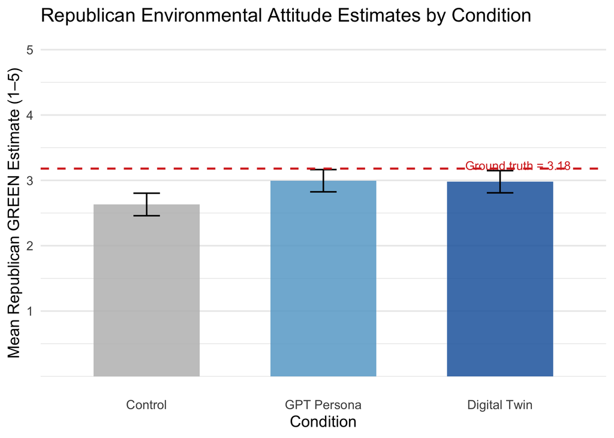

Figure 1: Mean Republican GREEN score estimates by condition. Error bars = 95% CI. Dashed red line = ground truth Republican mean.

```r
emm_ci <- as_tibble(summary(emm_acc, level = 0.95))
# EMMs are on abs_error; for the estimate plot, use green_estimate
emm_est <- emmeans(lm(green_estimate ~ treatment, data = dat), ~ treatment)
emm_est_ci <- as_tibble(summary(emm_est, level = 0.95))

p1 <- ggplot(emm_est_ci, aes(x = treatment, y = emmean, fill = treatment)) +
  geom_col(width = 0.6, alpha = 0.85) +
  geom_errorbar(aes(ymin = lower.CL, ymax = upper.CL), width = 0.15, linewidth = 0.6) +
  geom_hline(yintercept = GROUND_TRUTH_GREEN, linetype = "dashed", color = "#D73027", linewidth = 0.8) +
  annotate("text", x = 3.4, y = GROUND_TRUTH_GREEN + 0.05,
           label = paste0("Ground truth = ", GROUND_TRUTH_GREEN),
           color = "#D73027", hjust = 1, size = 3.5) +
  scale_fill_manual(values = condition_colors, guide = "none") +
  scale_y_continuous(limits = c(0, 5), breaks = 1:5) +
  labs(x = "Condition", y = "Mean Republican GREEN Estimate (1–5)",
       title = "Republican Environmental Attitude Estimates by Condition") +
  theme_minimal(base_size = 13) +
  theme(panel.grid.major.x = element_blank())

p1
ggsave(file.path(fig_path, "green_estimates_by_condition.png"), p1, width = 7, height = 5, dpi = 300)
```

### Figure 2: Absolute error by condition

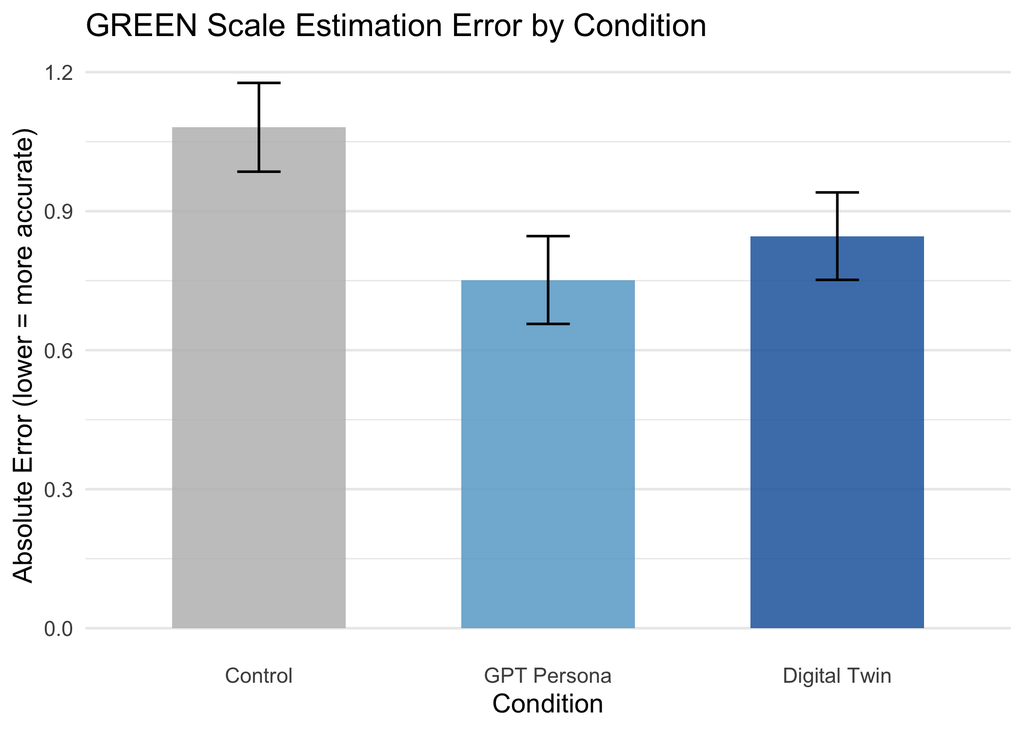

Figure 2: Mean absolute estimation error by condition (lower = more accurate). Error bars = 95% CI.

```r
emm_ci <- as_tibble(summary(emm_acc, level = 0.95))

p2 <- ggplot(emm_ci, aes(x = treatment, y = emmean, fill = treatment)) +
  geom_col(width = 0.6, alpha = 0.85) +
  geom_errorbar(aes(ymin = lower.CL, ymax = upper.CL), width = 0.15, linewidth = 0.6) +
  scale_fill_manual(values = condition_colors, guide = "none") +
  labs(x = "Condition", y = "Absolute Error (lower = more accurate)",
       title = "GREEN Scale Estimation Error by Condition") +
  theme_minimal(base_size = 13) +
  theme(panel.grid.major.x = element_blank())

p2
ggsave(file.path(fig_path, "abs_error_by_condition.png"), p2, width = 7, height = 5, dpi = 300)
```

### Item-level accuracy

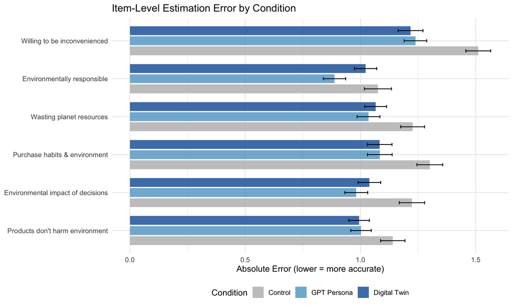

Item-level absolute error by condition. Lower = more accurate.

```r
item_labels <- c(
  "Products don't harm environment",
  "Environmental impact of decisions",
  "Purchase habits & environment",
  "Wasting planet resources",
  "Environmentally responsible",
  "Willing to be inconvenienced"
)

item_long <- dat %>%
  select(ResponseId, treatment, starts_with("abs_error_")) %>%
  pivot_longer(starts_with("abs_error_"), names_to = "item", values_to = "abs_error") %>%
  mutate(item = factor(item, levels = paste0("abs_error_", 1:6), labels = item_labels))

item_means <- item_long %>%
  group_by(treatment, item) %>%
  summarise(M = mean(abs_error, na.rm = TRUE),
            SE = sd(abs_error, na.rm = TRUE) / sqrt(n()),
            .groups = "drop")

p_items <- ggplot(item_means, aes(x = item, y = M, fill = treatment)) +
  geom_col(position = position_dodge(0.8), width = 0.7, alpha = 0.85) +
  geom_errorbar(aes(ymin = M - SE, ymax = M + SE),
                position = position_dodge(0.8), width = 0.25) +
  scale_fill_manual(values = condition_colors, name = "Condition") +
  labs(x = NULL, y = "Absolute Error (lower = more accurate)",
       title = "Item-Level Estimation Error by Condition") +
  coord_flip() +
  theme_minimal(base_size = 12) +
  theme(legend.position = "bottom")

p_items
```

```r
ggsave(file.path(fig_path, "item_accuracy_by_condition.png"), p_items, width = 10, height = 6, dpi = 300)
```

## Ad Persuasiveness

```r
m_pers <- aov(persuasive ~ treatment, data = dat %>% filter(!is.na(persuasive)))
pers_anova <- summary(m_pers)
pers_F <- pers_anova[[1]][["F value"]][1]
pers_p <- pers_anova[[1]][["Pr(>F)"]][1]
pers_df1 <- pers_anova[[1]][["Df"]][1]
pers_df2 <- pers_anova[[1]][["Df"]][2]
pers_eta2 <- pers_anova[[1]][["Sum Sq"]][1] / sum(pers_anova[[1]][["Sum Sq"]])

emm_pers <- emmeans(m_pers, ~ treatment)
pers_contrasts <- contrast(emm_pers, list(
  `Control − Twin`    = c(1, 0, -1),
  `Control − Persona` = c(1, -1, 0),
  `Persona − Twin`    = c(0, 1, -1)
)) %>% as_tibble()

pers_rmse <- sqrt(pers_anova[[1]][["Sum Sq"]][2] / pers_df2)

pers_contrasts %>%
  mutate(
    `Cohen's d` = numformat(estimate / pers_rmse),
    Estimate = numformat(estimate),
    SE = numformat(SE),
    `t-ratio` = numformat(t.ratio),
    `p-value` = map_chr(p.value, pformat)
  ) %>%
  select(Contrast = contrast, Estimate, SE, `t-ratio`, `p-value`, `Cohen's d`) %>%
  gt() %>%
  tab_header(title = "Planned Contrasts: Ad Persuasiveness") %>%
  tab_footnote("Negative estimate = first condition rated ad as LESS persuasive for Republicans.",
               locations = cells_title())
```

Planned Contrasts: Ad Persuasiveness<sup>1</sup>

| Contrast | Estimate | SE | t-ratio | p-value | Cohen's d |
| --- | --- | --- | --- | --- | --- |
| Control − Twin | -0.34 | 0.13 | -2.57 | = 0.011 | -0.31 |
| Control − Persona | -0.24 | 0.13 | -1.80 | = 0.072 | -0.22 |
| Persona − Twin | -0.10 | 0.13 | -0.76 | = 0.447 | -0.09 |

<sup>1</sup> Negative estimate = first condition rated ad as LESS persuasive for Republicans.

```r
ctrl_pers_M <- mean(dat$persuasive[dat$treatment == "Control"], na.rm = TRUE)
ctrl_pers_SD <- sd(dat$persuasive[dat$treatment == "Control"], na.rm = TRUE)
twin_pers_M <- mean(dat$persuasive[dat$treatment == "Digital Twin"], na.rm = TRUE)
twin_pers_SD <- sd(dat$persuasive[dat$treatment == "Digital Twin"], na.rm = TRUE)
pers_pers_M <- mean(dat$persuasive[dat$treatment == "GPT Persona"], na.rm = TRUE)
pers_pers_SD <- sd(dat$persuasive[dat$treatment == "GPT Persona"], na.rm = TRUE)

ct_pers <- pers_contrasts %>% filter(contrast == "Control − Twin")
cp_pers <- pers_contrasts %>% filter(contrast == "Control − Persona")
```

Participants in all conditions predicted that Republicans would find the eco-friendly ad relatively unpersuasive (all *M*s < 3 on a 1–5 scale). A one-way ANOVA revealed a significant effect of condition, *F*(2, 396) = 3.47, *p* = 0.032, η² = 0.017. The Digital Twin condition predicted significantly higher Republican ad persuasiveness than Control (Control *M* = 2.42, *SD* = 1.12; Digital Twin *M* = 2.76, *SD* = 1.12: *t* = -2.57, *p* = 0.011, *d* = -0.31).

### Figure 3: Ad persuasiveness by condition

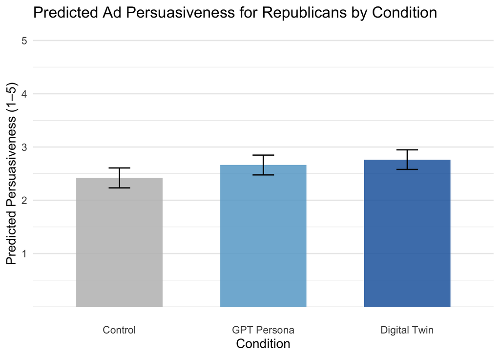

Figure 3: Mean predicted ad persuasiveness by condition. Error bars = 95% CI.

```r
emm_pers_ci <- as_tibble(summary(emm_pers, level = 0.95))

p3 <- ggplot(emm_pers_ci, aes(x = treatment, y = emmean, fill = treatment)) +
  geom_col(width = 0.6, alpha = 0.85) +
  geom_errorbar(aes(ymin = lower.CL, ymax = upper.CL), width = 0.15, linewidth = 0.6) +
  scale_fill_manual(values = condition_colors, guide = "none") +
  scale_y_continuous(limits = c(0, 5), breaks = 1:5) +
  labs(x = "Condition", y = "Predicted Persuasiveness (1–5)",
       title = "Predicted Ad Persuasiveness for Republicans by Condition") +
  theme_minimal(base_size = 13) +
  theme(panel.grid.major.x = element_blank())

p3
ggsave(file.path(fig_path, "persuasiveness_by_condition.png"), p3, width = 7, height = 5, dpi = 300)
```

## Chatbot Engagement

```r
# Turn count and engagement (only for chatbot conditions)
chat_dat <- dat %>%
  filter(treatment %in% c("GPT Persona", "Digital Twin") & !is.na(chatbot_turn_count))

if (nrow(chat_dat) > 10) {
  eng_test <- t.test(chatbot_turn_count ~ treatment, data = chat_dat)

  chat_dat %>%
    group_by(treatment) %>%
    summarise(
      N = n(),
      `Turns (M)` = numformat(mean(chatbot_turn_count, na.rm = TRUE)),
      `Turns (SD)` = numformat(sd(chatbot_turn_count, na.rm = TRUE)),
      .groups = "drop"
    ) %>%
    gt() %>%
    tab_header(title = "Chatbot Engagement by Condition")

  cat("Turns t-test: t =", numformat(eng_test$statistic), ", p", pformat(eng_test$p.value), "\n")

  # Does engagement predict accuracy?
  m_eng <- lm(abs_error ~ chatbot_turn_count * treatment, data = chat_dat)
  cat("\nEngagement → Absolute Error:\n")
  print(summary(m_eng))
} else {
  cat("Insufficient chatbot engagement data (N =", nrow(chat_dat), "with turn counts).\n")
}
```

```
Insufficient chatbot engagement data (N = 3 with turn counts).
```

## Combined Figure

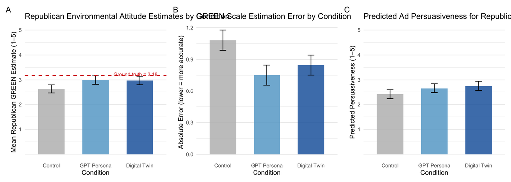

Summary of condition effects. (A) GREEN estimates relative to ground truth. (B) Absolute estimation error. (C) Predicted ad persuasiveness.

```r
p_combined <- p1 + p2 + p3 +
  plot_annotation(tag_levels = "A") +
  plot_layout(widths = c(1, 1, 1))

p_combined
```

```r
ggsave(file.path(fig_path, "combined_figure.png"), p_combined, width = 14, height = 5, dpi = 300)
```

## Summary

```r
all_contrasts <- bind_rows(
  acc_contrasts %>%
    mutate(Outcome = "Absolute Error", d = estimate / rmse) %>%
    select(Outcome, Contrast = contrast, b = estimate, SE, t = t.ratio, p = p.value, d),
  pers_contrasts %>%
    mutate(Outcome = "Persuasiveness", d = estimate / pers_rmse) %>%
    select(Outcome, Contrast = contrast, b = estimate, SE, t = t.ratio, p = p.value, d)
)

all_contrasts %>%
  mutate(
    b = numformat(b),
    SE = numformat(SE),
    t = numformat(t),
    p = map_chr(p, pformat),
    d = numformat(d)
  ) %>%
  gt() %>%
  tab_header(title = "Summary of All Planned Contrasts") %>%
  tab_footnote("For Abs. Error: positive b = first condition less accurate. For Persuasiveness: negative b = first condition rated ad as less persuasive for outgroup.",
               locations = cells_title())
```

Summary of All Planned Contrasts<sup>1</sup>

| Outcome | Contrast | b | SE | t | p | d |
| --- | --- | --- | --- | --- | --- | --- |
| Absolute Error | Control − Twin | 0.23 | 0.07 | 3.43 | < .001 | 0.42 |
| Absolute Error | Control − Persona | 0.33 | 0.07 | 4.81 | < .001 | 0.59 |
| Absolute Error | Persona − Twin | -0.09 | 0.07 | -1.39 | = 0.165 | -0.17 |
| Persuasiveness | Control − Twin | -0.34 | 0.13 | -2.57 | = 0.011 | -0.31 |
| Persuasiveness | Control − Persona | -0.24 | 0.13 | -1.80 | = 0.072 | -0.22 |
| Persuasiveness | Persona − Twin | -0.10 | 0.13 | -0.76 | = 0.447 | -0.09 |

<sup>1</sup> For Abs. Error: positive b = first condition less accurate. For Persuasiveness: negative b = first condition rated ad as less persuasive for outgroup.